# Guide pour le projet d'analyse de Données

### Analyse Univariée

Quelques conseils

```python
Bien identifier si une variable est qualitative,qualitative ordonnée ou quantitative.

Pour les variables qualitatives et qualitatives ordonnées:
    représenter les effectifs des données, ou les effectifs cumulés.
```

```python
Entrepreneurship_data.EducationSector.value_counts().keys()
```

```
Index(['Engineering Sciences',
       'Economic Sciences, Business Studies, Commerce and Law',
       'Art, Music or Design', 'Others', 'Medicine, Health Sciences',
       'Humanities and Social Sciences', 'Mathematics or Natural Sciences',
       'Teaching Degree (e.g., B.Ed)', 'Language and Cultural Studies'],
      dtype='object')
```

[figure not shown]

```python
# Un exemple sur une variable qualitative.

L = ['Engineering Sciences',
       'Economic Sciences, Business Studies, Commerce and Law',
       'Design', 'Others', 'Medicine, Health Sciences',
       'Humanities and Social Sciences', 'Mathematics or Natural Sciences',
       'Teaching', 'Language and Cultural Studies']

Rate = [40,15,10,5,5,10,14,1]

L_1 = []

for i,j in zip(L,Rate):
    L_1 += [i]*j

Ed = pd.DataFrame.from_dict({"Education":L_1})

import matplotlib.pyplot as plt


Ed_sector = Ed["Education"].value_counts()
labels = Ed_sector.keys()
sizes = Ed_sector
explode = (0.1,0,0, 0, 0, 0, 0, 0)  #

fig1, ax1 = plt.subplots(figsize=(7,7))
pie = ax1.pie(sizes, explode=explode, autopct='%1.1f%%',
        startangle=90,radius =1
        )

labels = ['{0} - {1:1.2f} %'.format(i, j) for i, j in zip(labels,
100.*slices/slices.sum())]
ax1.legend(pie[0], labels, loc='best', bbox_to_anchor=(0, 1), fontsize=8)

ax1.axis('equal')

plt.show()
```

```python
#Données Quantitative:
from numpy.random import normal
from scipy.stats import laplace_asymmetric
kappa = 0.01
u = arr = np.array([1.,2.,3.,4.,5.])
x = np.array([1.,4.,6.,9.,100.])

df_egalitaire = pd.DataFrame.from_dict({"Nombres":u})
df = pd.DataFrame.from_dict({"Nombres":x})
```

```python
def gini(array):
    """Calculate the Gini coefficient of a numpy array."""
    # based on bottom eq: http://www.statsdirect.com/help/content/image/stat0206_wmf.gif
    # from: http://www.statsdirect.com/help/default.htm#nonparametric_methods/gini.htm
    array = array.flatten() #all values are treated equally, arrays must be 1d
    if np.amin(array) < 0:
        array -= np.amin(array) #values cannot be negative
    array += 0.0000001 #values cannot be 0
    array = np.sort(array) #values must be sorted
    index = np.arange(1,array.shape[0]+1) #index per array element
    n = array.shape[0]#number of array elements
    return ((np.sum((2 * index - n  - 1) * array)) / (n * np.sum(array))) #Gini coefficient
```

```
0.6766666638472223
```

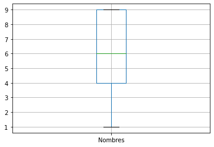

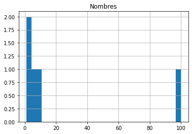

```python
df.boxplot(showfliers = False)
df.hist(bins=30)
gini(x)
```

```python
gini(u)
```

```
0.26666665777777804
```

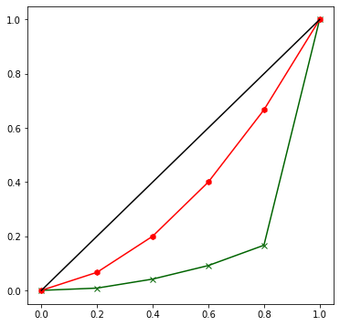

```python
X_lorenz = x.cumsum() / x.sum()
X_lorenz = np.insert(X_lorenz, 0, 0)
X_lorenz[0], X_lorenz[-1]


U_lorenz = u.cumsum() / u.sum()
U_lorenz = np.insert(U_lorenz, 0, 0)
U_lorenz[0], U_lorenz[-1]
fig, ax = plt.subplots(figsize=[6,6])
## scatter plot of Lorenz curve
ax.plot(np.arange(X_lorenz.size)/(X_lorenz.size-1), X_lorenz,
           marker='x', color='darkgreen')
ax.plot(np.arange(U_lorenz.size)/(U_lorenz.size-1), U_lorenz,
           marker='h', color='r')
## line plot of equality
ax.plot([0,1], [0,1], color='k')
```

u (en rouge) est moins inégalitaire que x !

### Analyse Multivariée

```python
Bien faire attention aux outliers dans les jeux de données.

Que compare-t-on avec quoi : Qualitatif avec Qualitatif -> Effectif croisé
                            Quantitatif avec Quantitaif -> pairplot et/ou matrice de corrélation)
                            Quantitatif avec Qualitatif -> >Boxplots

Les mesures d'association sont importantes aussi (cours 5)
(corrélation pour des variables quantitatives (bien choisir) ,
 chi_2 ou V de Cramer entre des variables qualitatives,
 et pour les qualitatives ordonnées: Tau_b de kendall ou tau_c de Stuart)

et entre qualitatives et quantitatives: rapport de corrélation.
```

##### EXEMPLE QUALITATIF/QUANTITATIF

```python
## EXEMPLE QUALITATIF/QUANTITATIF

from sklearn import datasets
with plt.style.context('seaborn-bright'):
    iris_data = datasets.load_iris()
    df_iris = pd.DataFrame(iris_data.data,columns=iris_data.feature_names)
    df_iris['espece'] = pd.Series(iris_data.target)
    df_iris.head()

    # Pour bien montrer que la variable espece n'est pas une qualitative ordonnée mais simplement une variable qualititaive
    # je renomme les modalités

    L=["Iris-Setosa","Iris-Versicolour","Iris-Virginica"]
    df_iris['espece'] = df_iris[['espece']].applymap(lambda x: L[x])

df_iris
```

|  | sepal length (cm) | sepal width (cm) | petal length (cm) | petal width (cm) | espece |
| --- | --- | --- | --- | --- | --- |
| 0 | 5.1 | 3.5 | 1.4 | 0.2 | Iris-Setosa |
| 1 | 4.9 | 3.0 | 1.4 | 0.2 | Iris-Setosa |
| 2 | 4.7 | 3.2 | 1.3 | 0.2 | Iris-Setosa |
| 3 | 4.6 | 3.1 | 1.5 | 0.2 | Iris-Setosa |
| 4 | 5.0 | 3.6 | 1.4 | 0.2 | Iris-Setosa |
| ... | ... | ... | ... | ... | ... |
| 145 | 6.7 | 3.0 | 5.2 | 2.3 | Iris-Virginica |
| 146 | 6.3 | 2.5 | 5.0 | 1.9 | Iris-Virginica |
| 147 | 6.5 | 3.0 | 5.2 | 2.0 | Iris-Virginica |
| 148 | 6.2 | 3.4 | 5.4 | 2.3 | Iris-Virginica |
| 149 | 5.9 | 3.0 | 5.1 | 1.8 | Iris-Virginica |

150 rows × 5 columns

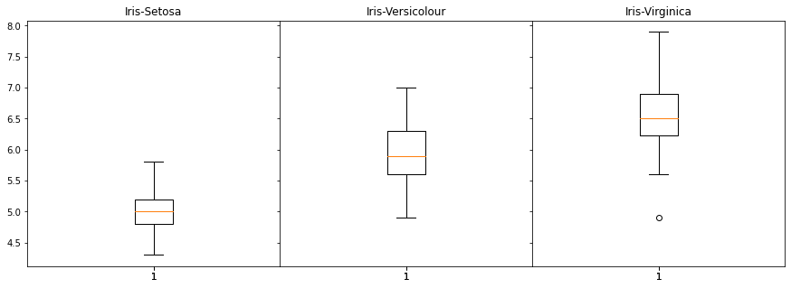

```python
    ##PLOTTING

    fig,axes = plt.subplots(1,3,sharex=True,sharey=True,figsize=(15,5))
    # Sharex et sharey portent bien leurs noms : si True, ils indiquent que les sous-graphiques
    # ont des axes paramétrés de la même manière

    c = ['#ff00b8','#ff8471','#ffa700']
    for i in range(1):
        for j in range(3):
            axes[j].boxplot(list(df_iris[df_iris['espece'] == L[j]].iloc[:,0]))


    # L'objet "axes" est un 2darray, simple à indicer et parcourir avec une boucle
            axes[j].set_title(L[j])
    # N'hésitez pas à faire varier les paramètres qui vous posent question. Par exemple, à quoi sert alpha ?
    plt.subplots_adjust(wspace=0,hspace=0)
    # Cette dernière méthode permet de supprimer les espaces entres les sous graphes.
```

```python
Une tendance semble être mise en avant.
```

Justifier les différents tests effectué avec la p-value !

### Contextualisation - Hypothèses

Une fois les premiers chiffres et graphes apparus, on peut avoir suffisamment d'élément pour répondre à la problématique énoncée initialement (peut-être même la reformuler pour mieux y répondre) Il ne faut pas hésiter à noter les observations que l'on a (même si elles semblent s'opposer!!!) Il faut ensuite justifier cette opposition. Je préfère un rapport qui met en avant les difficultés et oppositions à un rapport qui cache certains éléments.

### Recommandation de travail

Un point là dessus! Il est normal de faire des aller-retour entre les parties. Même si la présentation suit un plan bien définie il ne faut pas hésiter à revenir sur le formatage pour relancer des analyses univariées etc...